# Template - Lab 3: Exploring Happiness

Due: Thursday 10/03/2019 by 10 pm

Lynna Chu

09/26/2019

## Background

The General Social Survey (GSS) has been run by NORC every other year since 1972 to keep track of current opinions across the United States. We are working with an excerpt of the dataset that covers years 1972 to 2016. The variable names along with a brief description are as follows:

[output not shown]

Now it’s important to understand what each column stands for. You can find a codebook with explanations for each of the variables at https://gssdataexplorer.norc.org/

## Data Cleaning

```r
happy <- readRDS("C:/Users/Flame/Documents/ds202/lab3/HAPPY.rds")
head(happy)
```

```
##           HAPPY YEAR AGE    SEX       MARITAL         DEGREE       FINRELA
## 1 NOT TOO HAPPY 1972  23 FEMALE NEVER MARRIED       BACHELOR       AVERAGE
## 2 NOT TOO HAPPY 1972  70   MALE       MARRIED LT HIGH SCHOOL ABOVE AVERAGE
## 3  PRETTY HAPPY 1972  48 FEMALE       MARRIED    HIGH SCHOOL       AVERAGE
## 4 NOT TOO HAPPY 1972  27 FEMALE       MARRIED       BACHELOR       AVERAGE
## 5  PRETTY HAPPY 1972  61 FEMALE       MARRIED    HIGH SCHOOL ABOVE AVERAGE
## 6  PRETTY HAPPY 1972  26   MALE NEVER MARRIED    HIGH SCHOOL ABOVE AVERAGE
##      HEALTH WTSSALL          PARTYID POLVIEWS
## 1      GOOD  0.4446     IND,NEAR DEM      IAP
## 2      FAIR  0.8893 NOT STR DEMOCRAT      IAP
## 3 EXCELLENT  0.8893      INDEPENDENT      IAP
## 4      GOOD  0.8893 NOT STR DEMOCRAT      IAP
## 5      GOOD  0.8893  STRONG DEMOCRAT      IAP
## 6      GOOD  0.4446     IND,NEAR DEM      IAP
```

```r
happy2 <- happy # this df has all of the missing vallues repersented with the same char
for(i in length(happy2)) happy2[i][happy2[i]=="IAP"||happy2[i]=="DK"]<- "NA"
head(happy2)
```

```
##           HAPPY YEAR AGE    SEX       MARITAL         DEGREE       FINRELA
## 1 NOT TOO HAPPY 1972  23 FEMALE NEVER MARRIED       BACHELOR       AVERAGE
## 2 NOT TOO HAPPY 1972  70   MALE       MARRIED LT HIGH SCHOOL ABOVE AVERAGE
## 3  PRETTY HAPPY 1972  48 FEMALE       MARRIED    HIGH SCHOOL       AVERAGE
## 4 NOT TOO HAPPY 1972  27 FEMALE       MARRIED       BACHELOR       AVERAGE
## 5  PRETTY HAPPY 1972  61 FEMALE       MARRIED    HIGH SCHOOL ABOVE AVERAGE
## 6  PRETTY HAPPY 1972  26   MALE NEVER MARRIED    HIGH SCHOOL ABOVE AVERAGE
##      HEALTH WTSSALL          PARTYID POLVIEWS
## 1      GOOD  0.4446     IND,NEAR DEM       NA
## 2      FAIR  0.8893 NOT STR DEMOCRAT       NA
## 3 EXCELLENT  0.8893      INDEPENDENT       NA
## 4      GOOD  0.8893 NOT STR DEMOCRAT       NA
## 5      GOOD  0.8893  STRONG DEMOCRAT       NA
## 6      GOOD  0.4446     IND,NEAR DEM       NA
```

Variables were also cast into the correct type in order to ease data visualization. This was done by:

```r
for(i in happy2$age) tryCatch(strtoi(happy2$age[i]))
```

```r
#head(happy2)
#happySort <- happy2[order(happy2$happy,happy2$marital,happy2$degree,happy2$health,happy2$finrela,happy2$sex,happy2$ag#e,happy2$year),]
#head(happySort)
```

## Data Exploration

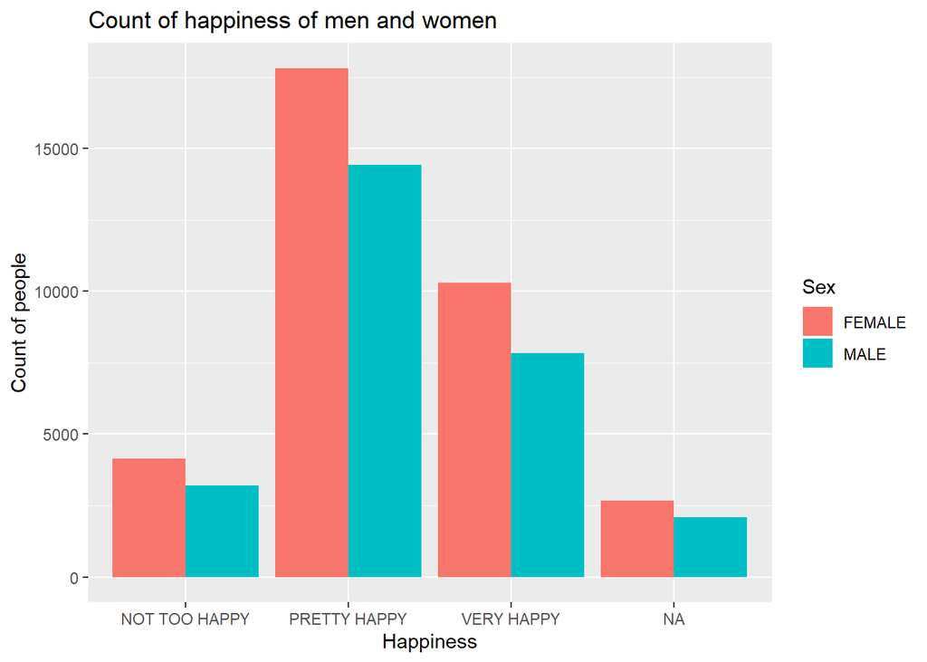

```r
library(ggplot2)
#insert relevant R code here
#include graphics. DESCRIBE your plot in context. Make sure it includes axis labels and appropriate title.
happy <- readRDS("C:/Users/Flame/Documents/ds202/lab3/HAPPY.rds")
happy2 <- happy # this df has all of the missing vallues repersented with the same char
for(i in length(happy2)) happy2[i][happy2[i]=="IAP"||happy2[i]=="DK"]<- "NA"
ggplot(data = happy2, aes(x = happy2$HAPPY, fill = happy2$SEX) ) + geom_bar(position = position_dodge()) +xlab("Happiness") + ylab("Count of people") + ggtitle("Count of happiness of men and women") + labs(fill = "Sex")
```

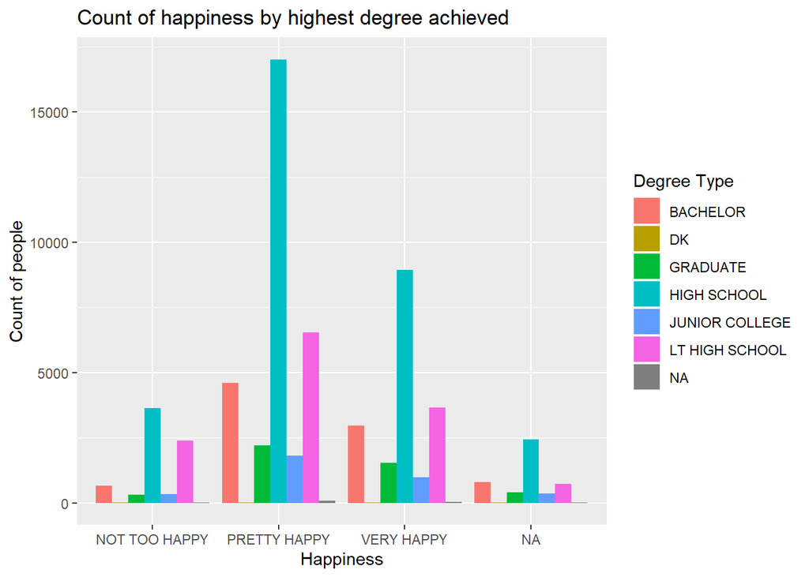

```r
ggplot(data = happy2, aes(x = happy2$HAPPY, fill = happy2$DEGREE) ) + geom_bar(position = position_dodge()) +xlab("Happiness") + ylab("Count of people") + ggtitle("Count of happiness by highest degree achieved") + labs(fill = "Degree Type")
```

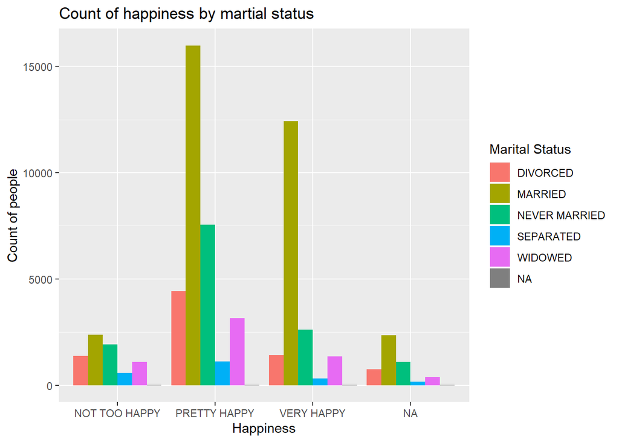

```r
ggplot(data = happy2, aes(x = happy2$HAPPY, fill = happy2$MARITAL) ) + geom_bar(position = position_dodge()) +xlab("Happiness") + ylab("Count of people") + ggtitle("Count of happiness by martial status") + labs(fill = "Marital Status")
```

The distributions for sex and happiness seem to suggest that sex does not have much of an effect on happiness. For the second graph, the graph seems to skewed left for people who are in high school or higher. For marital status, married couples are skewed left. This seems to imply that people who have finished a high school degree or higher and whose marital status is married have a better self view of their lives.